# MasterClass: Predictive Analytics in Insurance

By *Rendani Mbuvha*

# *Predictive Analytics in Insurance*

This notebook will provide all the interactive material for the MasterClass: Predictive Analytics in Insurance workshop. The workshop will cover:

- Traditional statistical analysis
- Machine Learning Techniques
  - Supervised learning techniques
  - Unsupervised learning techniques

The workshop will be based on data from the Computational Actuarial Science Package

## **Preliminaries - To be done before the workshop**

**Workshop attendees are requested to bring their own laptops with the programmes and packages below installed.**

First of all, we need to install R, R studio, and the required packages.

- Download and install R according to the instructions [here](https://cran.rstudio.com/)
- Download and install R studio according to instructions [here](https://www.rstudio.com/products/rstudio/download/#download)

In R, install the following libraries:

- ROCR
- ggplot2
- CASdatasets

> Using *install.packages(“CASdatasets”, repos = “http://cas.uqam.ca/pub/R/”, type=“source”)*
- rpart
- fitdistrplus
- h2o
- tree
- som
- class
- ISLR
- corrplot
- pROC
- caret

> Use the command on the R console *install.packages(“package-name”)*

## **Recommended Introductory R Material**

While the workshop will briefly touch on some basics of R. R will mainly be used as an analysis tool. Some good introductory R material can be found here:

- [Radford Neal’s R Course](http://www.cs.utoronto.ca/~radford/csc121.S17/) (Browsing through weeks 1-4 is sufficient)
- [Introduction to some aspects of R (Chi Yau)](http://www.r-tutor.com/r-introduction)

## Loading Libraries

Pre-made libraries are the most efficient way to work in R. This allows one to use already defined functions in-order to run functions or fit models they require.

The statement below will load the library CASdatasets which contains most of the datasets that we will use in this workshop.

Set working directory to the folder where you would to save your work.

```r
setwd("~/Dropbox/Masterclass")

#for windows
#dir.create("C:/Documents/Masterclass")
#setwd("C:/Documents/Masterclass")
rm(list=ls()) #clear workspace
```

```r
library(knitr)
library(CASdatasets) #mainly datasets
library(ROCR)
library(rpart.plot)
library(rpart)
library(caret)
library(h2o)
library(pROC)
library(corrplot)
```

How to find help

```r
?help
```

## R Basics

The vector is the basic unit of computations in R

```r
x = c(1,3,2,5)
x
```

```r
x = c(1,6,2)
x
```

Adding vectors

```r
y = c(1,4,3)
length(x)
length(y)
x+y
```

Listing and removing variables to the workspace

```r
ls()
rm(x,y)
ls()
```

Creating matrices

```r
?matrix #calling help webpage
x=matrix(data=c(1,2,3,4), nrow=2, ncol=2)
x
```

Some mathematical functions

```r
matrix(c(1,2,3,4),2,2,byrow=TRUE)
sqrt(x)
x^2
#Random Sample from Standard Normal
x=rnorm(50)
y=x+rnorm(50,mean=50,sd=.1)
#Correlation Matrix
cor(x,y)
```

```r
set.seed(1303)
rnorm(50)
set.seed(3)
y=rnorm(100)
mean(y)
var(y)
sqrt(var(y))
sd(y)
```

```r
# Graphics

x=rnorm(500)
y=rnorm(500)
plot(x,y)
plot(x,y,xlab="x-axis",ylab="y-axis",main="Plot of X vs Y")
pdf("Figure.pdf")
plot(x,y,col="green")
dev.off()
```

```r
# Indexing Data

A=matrix(1:16,4,4)
```

```r
A
```

```r
A[2,3]
```

```r
A[c(1,3),c(2,4)]
```

```r
A[1:3,2:4]
```

```r
A[1:2,]
```

```r
A[,1:2]
```

```r
A[1,]
```

```r
A[-c(1,3),]
```

```r
A[-c(1,3),-c(1,3,4)]
```

```r
dim(A)
```

# Bank Marketing Data Set

The data is related with direct marketing campaigns of a Portuguese banking institution. The marketing campaigns were based on phone calls. Often, more than one contact to the same client was required, in order to access if the product (bank term deposit) would be (‘yes’) or not (‘no’) subscribed.

Download it [here](https://www.dropbox.com/s/cri0nyx66yttq4m/bank-additional.zip?dl=0)

```r
# Loading Data from csv
Bank = read.csv("bank-full.csv",header=T,sep = ";")
```

```r
dim(Bank)
```

```r
head(Bank)
```

Removing Nulls

```r
Bank=na.omit(Bank)
```

Number of dimensions

```r
dim(Bank)
```

Names of variables

```r
names(Bank)
```

## Data Visualisation -Advanced Graphics

Find Correlations

```r
numerical_vars = sapply(Bank, is.numeric)

corrm = cor(Bank[ , numerical_vars], use = "complete.obs")

corrplot(corrm, method = "circle", tl.cex = 0.5)
```

```r
ggplot(Bank, aes(x=education, y = age, fill=education)) +
  geom_boxplot()
```

```r
ggplot(Bank, aes(x = balance, fill = education)) +
  geom_density()+xlim(-10,10000)
```

```r
ggplot(Bank, aes(balance)) +
  geom_density() +
  facet_wrap(c("education",'y'), labeller = "label_both", scales = "free")+xlim(-1000,10000)
```

## Traditional Statistical Methods

Here we will explore performing statistical inference on data sets using Traditional frequentist methods.

## Distribution fitting

Load package that contains functions for fitting parametric distributions to data.

```r
library(fitdistrplus)
```

Lets explore fitting some distributions to the *itamtplcost* which contains large claims (>500 Euro) of Italian Motor-TPL company since 1997.To find out more about the data set use the “help” function.

```r
help(itamtplcost)
```

```r
data("itamtplcost") #load the dataset
head(itamtplcost) #see some of the top rows
summary(itamtplcost$UltimateCost) #lets see some summmary statistics of the Ultimate costs
```

Lets fit the Gamma distribution to the data using maximum likelihood.

```r
x = itamtplcost$UltimateCost / 1000000 # Creating a separate scaled variable for claims cost
gamma_mle = fitdist(x, "gamma", method = "mle")
plot(gamma_mle) #Plots the density function and some diagnostic plots
summary(gamma_mle) #get a summary of the fit including the estimated parameters
```

Consider what would happen if you fit a normal distribution instead

```r
norm_mle = fitdist(x, "norm", method = "mle")
plot(norm_mle) #Plots the density function and some diagnostic plots
summary(norm_mle)
```

Remember that AIC = $-\frac{2}{N} * loglik + 2\frac{d}{N}$

One can also check for outliers using boxplots

```r
boxplot(x, col = "green", main = "Boxplot of Ultimate Claims Cost")
```

# Simple Regression

We will now show how one can perform regression using the *freMTPLfreq* data set which contains risk features and claim numbers of around 413 169 of a French insurer.

```r
help(freMTPLfreq)
```

```r
data(freMTPLfreq)
head(freMTPLfreq) #see some of the first rows
summary(freMTPLfreq)
```

One can create some bins for continuous variables like DriveAge and CarAge using the cut function.

```r
freMTPLfreq$DriverAge_bin = cut(freMTPLfreq$DriverAge,breaks = c(0,25,30,40,50,60,70,Inf),right = FALSE) # This "cuts" DriverAge into bins

freMTPLfreq$CarAge_bin = cut(freMTPLfreq$CarAge,breaks = c(0,2,5,10,15,Inf),right = FALSE) # This "cuts" DriverAge into bins

freMTPLfreq$Density_bin = cut(freMTPLfreq$Density,breaks = c(0,50,100,500,1500,5000,10000,Inf),right = FALSE) # This "cuts" DriverAge into bins
summary(freMTPLfreq)
```

Lets build a regression model to predict the number of claims per unit exposure given the risk characteristics. Assuming that the number of claims follows a Poisson distribution.

Lets assume that we don’t know whether to use the continuous variables above of the binned ones

```r
pois_reg = glm(ClaimNb ~ Gas+CarAge+DriverAge+Density+Brand+CarAge_bin+DriverAge_bin+Density_bin,offset = log(Exposure), data = freMTPLfreq,family = poisson(link=log))
summary(pois_reg)
```

We see that some of the variables are not significant perhaps we could perform some variable selection to see which combinations of variables yields the best model.

```r
pois_null =glm(ClaimNb ~ 1 ,offset = log(Exposure), data = freMTPLfreq,family = poisson(link=log))

step(pois_null, scope=list(lower=pois_null, upper=pois_reg), direction="forward")
```

Also note that there might some factor levels that are insignificant, this typically means that they should re-group together to create new factor levels. For example the Brand variable can be re-grouped into “BrandJapanese (except Nissan) or Korean” and “other”

```r
pruned_reg =glm(ClaimNb ~ Gas+Brand+CarAge_bin+DriverAge_bin+Density_bin,offset = log(Exposure), data = freMTPLfreq,family = poisson(link=log))
summary(pruned_reg)
```

## Supervised Machine Learning Techniques

This section will now focus on supervised learning techniques.

Here we will be using the German Credit Dataset. This dataset contains information of 1,000 credit records.

Look at the data and see what it?s about:

```r
data("credit")
help("credit")
```

summary of the variables

```r
summary(credit)
```

```
 checking_status    duration    credit_history    purpose    credit_amount   savings
 A11:274         Min.   : 4.0   A30: 40        A43    :280   Min.   :  250   A61:603
 A12:269         1st Qu.:12.0   A31: 49        A40    :234   1st Qu.: 1366   A62:103
 A13: 63         Median :18.0   A32:530        A42    :181   Median : 2320   A63: 63
 A14:394         Mean   :20.9   A33: 88        A41    :103   Mean   : 3271   A64: 48
                 3rd Qu.:24.0   A34:293        A49    : 97   3rd Qu.: 3972   A65:183
                 Max.   :72.0                  A46    : 50   Max.   :18424
                                               (Other): 55
 employment installment_rate personal_status other_parties residence_since
 A71: 62    Min.   :1.000    A91: 50         A101:907      Min.   :1.000
 A72:172    1st Qu.:2.000    A92:310         A102: 41      1st Qu.:2.000
 A73:339    Median :3.000    A93:548         A103: 52      Median :3.000
 A74:174    Mean   :2.973    A94: 92                       Mean   :2.845
 A75:253    3rd Qu.:4.000                                  3rd Qu.:4.000
            Max.   :4.000                                  Max.   :4.000

 property_magnitude      age        other_payment_plans housing    existing_credits
 A121:282           Min.   :19.00   A141:139            A151:179   Min.   :1.000
 A122:232           1st Qu.:27.00   A142: 47            A152:713   1st Qu.:1.000
 A123:332           Median :33.00   A143:814            A153:108   Median :1.000
 A124:154           Mean   :35.55                                  Mean   :1.407
                    3rd Qu.:42.00                                  3rd Qu.:2.000
                    Max.   :75.00                                  Max.   :4.000

   job      num_dependents  telephone  foreign_worker     class
 A171: 22   Min.   :1.000   A191:596   A201:963       Min.   :0.0
 A172:200   1st Qu.:1.000   A192:404   A202: 37       1st Qu.:0.0
 A173:630   Median :1.000                             Median :0.0
 A174:148   Mean   :1.155                             Mean   :0.3
            3rd Qu.:1.000                             3rd Qu.:1.0
            Max.   :2.000                             Max.   :1.0
```

Lets do some processing

```r
credit$class = factor(credit$class)
age_d = quantile(credit$age,seq(0,1,by=0.1)) #discretise age into deciles
credit$age=cut(credit$age,age_d)
```

Create and training - test data split

```r
 #convert class into discrete
n_records_gc = nrow(credit)
n_train_gc = round(0.7*n_records_gc,0)
training_ids = sample(1:n_records_gc,n_train_gc)
testing_ids = setdiff(1:n_records_gc,training_ids)
#Creating  subsets.
training_gc= credit[training_ids,]
testing_gc = credit[testing_ids,]
head(training_gc)
```

```
    checking_status duration credit_history purpose credit_amount savings employment
391             A14       18            A32     A40          1820     A61        A73
503             A13        9            A32     A43          1126     A62        A75
991             A14       12            A34     A46          3565     A65        A72
203             A14       27            A33     A49          5117     A61        A74
197             A14        6            A34     A43          1382     A61        A73
714             A11        9            A34     A43          1138     A61        A73
    installment_rate personal_status other_parties residence_since property_magnitude
391                2             A94          A101               2               A122
503                2             A91          A101               4               A121
991                2             A93          A101               1               A122
203                3             A93          A101               4               A123
197                1             A92          A101               1               A123
714                4             A93          A101               4               A121
        age other_payment_plans housing existing_credits  job num_dependents telephone
391 (28,30]                A143    A152                1 A174              1      A192
503 (45,52]                A143    A152                1 A173              1      A191
991 (36,39]                A143    A152                2 A172              2      A191
203 (23,26]                A143    A152                2 A173              1      A191
197 (26,28]                A143    A152                2 A173              1      A192
714 (23,26]                A143    A152                2 A172              1      A191
    foreign_worker class
391           A201     0
503           A201     0
991           A201     0
203           A201     0
197           A201     0
714           A201     0
```

What is the balance of classes in the different data splits

```r
print("Full Dataset")
```

```
[1] "Full Dataset"
```

```r
table(credit$class)
```

```
  0   1
700 300
```

```r
print("Training Dataset")
```

```
[1] "Training Dataset"
```

```r
table(training_gc$class)
```

```
  0   1
480 220
```

```r
print("Testing Dataset")
```

```
[1] "Testing Dataset"
```

```r
table(testing_gc$class)
```

```
  0   1
220  80
```

```r
glm.logistic = glm(class ~ checking_status+duration+purpose+other_parties+savings, data = training_gc, family = binomial(link = "logit"))
summary(glm.logistic)
```

```
Call:
glm(formula = class ~ checking_status + duration + purpose +
    other_parties + savings, family = binomial(link = "logit"),
    data = training_gc)

Deviance Residuals:
    Min       1Q   Median       3Q      Max
-2.1502  -0.7953  -0.4585   0.9141   2.6274

Coefficients:
                     Estimate Std. Error z value Pr(>|z|)
(Intercept)         -0.407275   0.259131  -1.572 0.116022
checking_statusA12  -0.243229   0.227911  -1.067 0.285877
checking_statusA13  -1.399152   0.412669  -3.390 0.000698 ***
checking_statusA14  -1.753380   0.252553  -6.943 3.85e-12 ***
duration             0.039677   0.007906   5.019 5.20e-07 ***
purposeA41          -1.087781   0.372314  -2.922 0.003482 **
purposeA410         -0.916395   0.762178  -1.202 0.229233
purposeA42          -0.226305   0.274347  -0.825 0.409436
purposeA43          -0.695570   0.265585  -2.619 0.008819 **
purposeA44           0.626872   0.902953   0.694 0.487528
purposeA45          -0.126148   0.649915  -0.194 0.846099
purposeA46           0.710168   0.409705   1.733 0.083031 .
purposeA48         -14.323999 552.625543  -0.026 0.979321
purposeA49          -0.371833   0.359075  -1.036 0.300421
other_partiesA102    0.705302   0.473324   1.490 0.136197
other_partiesA103   -0.904446   0.415119  -2.179 0.029349 *
savingsA62          -0.131973   0.304776  -0.433 0.665004
savingsA63          -0.909127   0.488428  -1.861 0.062697 .
savingsA64          -0.976342   0.530072  -1.842 0.065489 .
savingsA65          -0.751079   0.298788  -2.514 0.011945 *
---
Signif. codes:  0 ‘***’ 0.001 ‘**’ 0.01 ‘*’ 0.05 ‘.’ 0.1 ‘ ’ 1

(Dispersion parameter for binomial family taken to be 1)

    Null deviance: 871.48  on 699  degrees of freedom
Residual deviance: 705.91  on 680  degrees of freedom
AIC: 745.91

Number of Fisher Scoring iterations: 14
```

Test the model fit on testing set

```r
glm_pred= predict(glm.logistic, newdata = testing_gc, type = 'response') # use the model to #make predictions on the testing set.
```

Evaluate model performance

```r
#Create a prediction object
glm.prediction = prediction(glm_pred, testing_gc$class)
#infer True positive and false positive rates
glm.perf = performance(glm.prediction, measure = "tpr", x.measure = "fpr")

#accuracy and area under the curve
glm.acc = performance(glm.prediction, measure = "acc")
glm.auc = performance(glm.prediction, measure = "auc")
```

Plot accuracy at different cutoffs

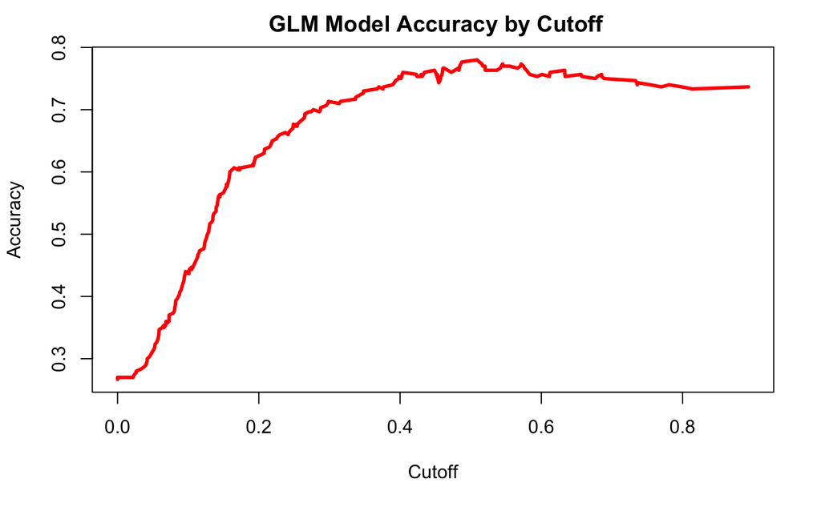

```r
plot(glm.acc,main=" GLM Model Accuracy by Cutoff",lwd=3,col=rainbow(10))
```

Using Decision Trees

```r
tree = rpart(class~ checking_status+duration+purpose+other_parties+savings, data = training_gc)
#make predictions on testing set
tree_pred = predict(tree,testing_gc)[,2]
```

Visualise the Tree Created

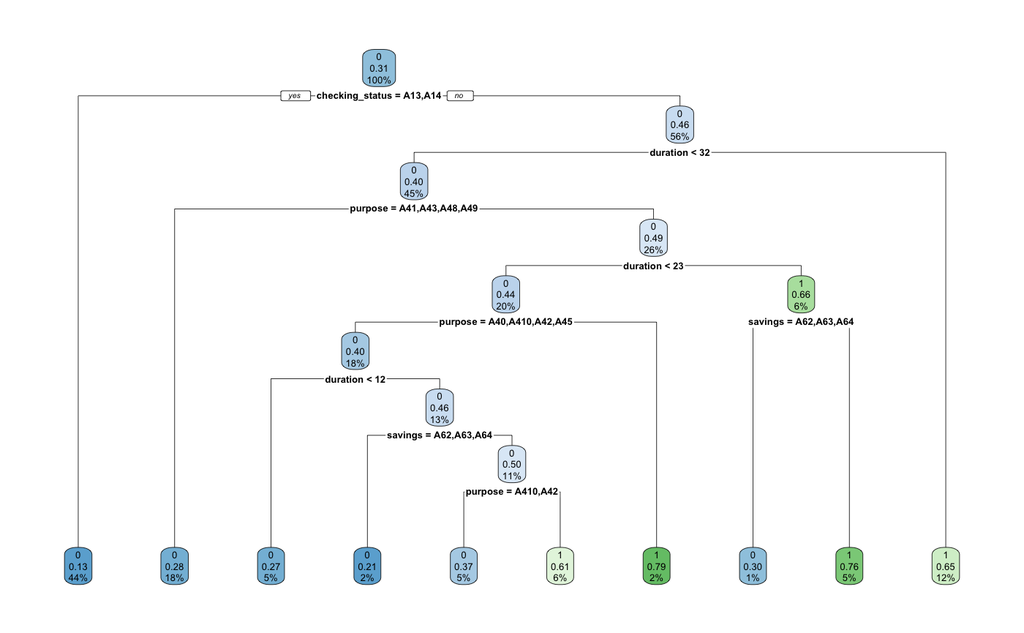

```r
rpart.plot(tree)
```

```r
rpart.rules(tree)
```

```
 class
  0.13 when checking_status is A13 or A14
  0.21 when checking_status is A11 or A12 & duration is 12 to 23 & purpose is               A40 or A410 or A42 or A45 & savings is A62 or A63 or A64
  0.27 when checking_status is A11 or A12 & duration <  12       & purpose is               A40 or A410 or A42 or A45
  0.28 when checking_status is A11 or A12 & duration <  32       & purpose is                A41 or A43 or A48 or A49
  0.30 when checking_status is A11 or A12 & duration is 23 to 32 & purpose is A40 or A410 or A42 or A44 or A45 or A46 & savings is A62 or A63 or A64
  0.37 when checking_status is A11 or A12 & duration is 12 to 23 & purpose is                             A410 or A42 & savings is        A61 or A65
  0.61 when checking_status is A11 or A12 & duration is 12 to 23 & purpose is                              A40 or A45 & savings is        A61 or A65
  0.65 when checking_status is A11 or A12 & duration >=       32
  0.76 when checking_status is A11 or A12 & duration is 23 to 32 & purpose is A40 or A410 or A42 or A44 or A45 or A46 & savings is        A61 or A65
  0.79 when checking_status is A11 or A12 & duration <  23       & purpose is                              A44 or A46
```

initialize h2o

```r
localH2O = h2o.init()
```

```
 Connection successful!

R is connected to the H2O cluster:
    H2O cluster uptime:         1 days 1 hours
    H2O cluster timezone:       Africa/Nairobi
    H2O data parsing timezone:  UTC
    H2O cluster version:        3.20.0.2
    H2O cluster version age:    2 months and 12 days
    H2O cluster name:           H2O_started_from_R_rendanimbuvha_cva598
    H2O cluster total nodes:    1
    H2O cluster total memory:   1.60 GB
    H2O cluster total cores:    4
    H2O cluster allowed cores:  4
    H2O cluster healthy:        TRUE
    H2O Connection ip:          localhost
    H2O Connection port:        54321
    H2O Connection proxy:       NA
    H2O Internal Security:      FALSE
    H2O API Extensions:         XGBoost, Algos, AutoML, Core V3, Core V4
    R Version:                  R version 3.5.1 (2018-07-02)
```

```r
h2o.removeAll(timeout_secs = 30)
```

```
[1] 30
```

Convert Dataframes to h2o format

```r
training_gc.hex = as.h2o(training_gc)
test_gc.hex = as.h2o(testing_gc)
```

```r
predictors =c( "checking_status","duration","credit_history","purpose","credit_amount","savings","employment","installment_rate","personal_status","other_parties" , "residence_since","property_magnitude", "age","other_payment_plans", "housing", "existing_credits","job","num_dependents","telephone","foreign_worker")
target ="class"
```

Fit Random Forest

```r
rf_fit = h2o.randomForest(
    training_frame = training_gc.hex, nfolds = 2,
    keep_cross_validation_predictions = TRUE,  x = predictors,  y = target,
    ntrees = 100,
    stopping_rounds = 2,
    score_each_iteration = TRUE
)
#Make predictions for the testing set
rf_pred = predict(rf_fit, test_gc.hex)
rf_pred_vec = as.vector(rf_pred$p1)
```

Obtain Variable importance Plot

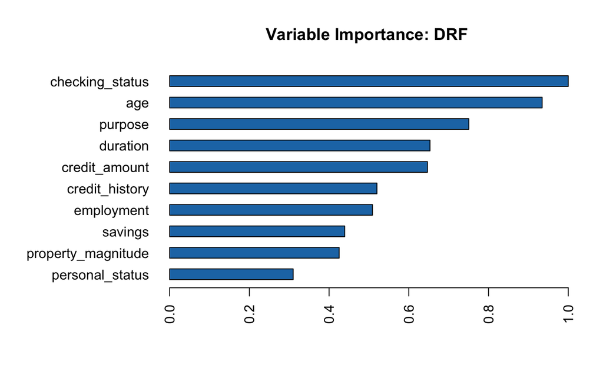

```r
h2o.varimp_plot(rf_fit)
```

# XGboost

Fit xgboost which is just a computationally efficient gradient boosting with penalty for more complex trees

```r
xgboost_fit = h2o.xgboost(
    training_frame = training_gc.hex, nfolds = 5,
    keep_cross_validation_predictions = TRUE,  x = predictors,  y = target,
    ntrees = 100,
    stopping_rounds = 2,
    score_each_iteration = TRUE
)
#Make predictions for the testing set
xgb_pred = predict(xgboost_fit, test_gc.hex)
xgb_pred_vec = as.vector(xgb_pred$p1)
```

```r
h2o.varimp_plot(xgboost_fit)
```

# Gradient Boosting Machine

```r
gbm_fit = h2o.gbm(
  training_frame = training_gc.hex,
  nfolds = 2,
  keep_cross_validation_predictions = TRUE,
  x = predictors,
  y = target
  )
#Make predictions for the testing set
gbm_pred = predict(gbm_fit, test_gc.hex)
gbm_pred_vec = as.vector(gbm_pred$p1)
```

```r
h2o.varimp_plot(gbm_fit)
```

# Neural Network

```r
nn_fit = h2o.deeplearning(x = predictors,
                       y = target,
                       training_frame = training_gc.hex,
                       nfolds = 5,
                       distribution = "AUTO",
                       activation = "TanhWithDropout",
                       hidden = c(50, 50, 50),
                       input_dropout_ratio = 0.1,
                       sparse = TRUE,
                       l1 = 0.001,
                       epochs = 1000,
                       keep_cross_validation_predictions = TRUE,
                       variable_importances = TRUE)
                       #quantile_alpha = 0.8)

#Make predictions for the testing set
nn_pred = predict(nn_fit, test_gc.hex)
nn_pred_vec = as.vector(nn_pred$p1)
```

```r
h2o.varimp_plot(nn_fit)
```

```r
roc_glm = plot.roc(testing_gc$class, glm_pred, main="ROC Comparison", col="black",auc=TRUE)
roc_tree = lines.roc(testing_gc$class, tree_pred, col="red")
roc_rf = lines.roc(testing_gc$class, rf_pred_vec, col="blue")
roc_xgb = lines.roc(testing_gc$class, xgb_pred_vec, col="green")
roc_gbm = lines.roc(testing_gc$class, gbm_pred_vec, col="orange")
roc_nn = lines.roc(testing_gc$class, nn_pred_vec, col="purple")

legend("bottomright", legend=c(paste("GLM AUC = ", round(auc(roc_glm),2)), paste("D TREE AUC = ", round(auc(roc_tree),2)), paste("RF AUC = ", round(auc(roc_rf),2)), paste("XGB AUC = ", round(auc(roc_xgb),2)),  paste("GBM AUC = ", round(auc(roc_gbm),2)),paste("NN AUC = ", round(auc(roc_nn),2))), col=c("black", "red", "blue", "green","orange", "purple"), lwd=3, bty = "n")
```

[output not shown]

# Tuning Parameters

The models above seem to give an okay performance but rather these were obtained using “Default” *hyperparameters* which are parameters of parameters of the model. One can improve this search for the right hyperparamters. This can be computationally intensive and is done by greedily or randomly searching the hyperparameter space.

Tuning the GBM

```r
#we are going to create a list of hyperparameters to search for
ntrees_opt = c(100)

learn_rate_opt = seq(0.01, 0.2, 0.01)


max_depth_opt = seq(3, 10)

sample_rate_opt = c(0.8, 1.0)
col_sample_rate_opt = c(0.6, 0.8, 1)

gbm_hyper_params = list(ntrees = ntrees_opt,
                    learn_rate = learn_rate_opt,
                     max_depth = max_depth_opt,
                     sample_rate = sample_rate_opt,
                     col_sample_rate = col_sample_rate_opt
                    )
search_criteria = list(strategy = "RandomDiscrete",
                        max_runtime_secs = 4000,
                        max_models = 30
                        )

## GBM gridsearch
gbm_fit_grid = h2o.grid(
  algorithm = "gbm",
  grid_id = "gbm_grid",
  x = predictors,
  y = target,
  hyper_params = gbm_hyper_params,
  search_criteria = search_criteria,
  training_frame = training_gc.hex,
  nfolds = 5,
  keep_cross_validation_predictions = TRUE,
  stopping_rounds = 2,
  stopping_tolerance = 1e-3,
  stopping_metric = "AUTO"
  )

sorted_grid_gbm = h2o.getGrid(grid_id = "gbm_grid", sort_by = "AUC", decreasing = TRUE)
print(sorted_grid_gbm)
gbm_fit_tuned_f = h2o.getModel(sorted_grid_gbm@model_ids[[1]])

#predict on testing set
gbm_tuned_pred = predict(gbm_fit_tuned_f, test_gc.hex)
gbm_tuned_pred_vec = as.vector(gbm_tuned_pred$p1)
```

Tuning the Neural Network

```r
structure = list(c(50, 50, 50),c(30, 30, 30),c(50, 60, 50))
learning_rates = c(1e-3,1e-4)


drop_outs = c(0.1, 0.2)

nn_hyperparameters = list(hidden = structure , l1 = learning_rates,  input_dropout_ratio = drop_outs)

search_criteria = list(strategy = "RandomDiscrete",
                        max_runtime_secs = 4000,
                        max_models = 40
                        )

nn_model_grid = h2o.grid("deeplearning",
  grid_id = "nn_grid",
  hyper_params = nn_hyperparameters,
  x = predictors,
  y = target,
  distribution = "AUTO",
  activation = "TanhWithDropout",
  training_frame = training_gc.hex,
  nfolds = 2,
  stopping_rounds = 3,
  epochs = 1000,
  search_criteria = search_criteria,
  stopping_tolerance = 0.05,
  stopping_metric = "AUC")

sorted_grid_nn = h2o.getGrid(grid_id = "nn_grid", sort_by = "AUC", decreasing = TRUE)
print(sorted_grid_nn)
nn_fit_tuned_f = h2o.getModel(sorted_grid_nn@model_ids[[1]])

#predict on testing set
nn_tuned_pred = predict(nn_fit_tuned_f, test_gc.hex)
nn_tuned_pred_vec = as.vector(nn_tuned_pred$p1)
```

Lets check performance again

```r
roc_gbm_t = plot.roc(testing_gc$class, gbm_tuned_pred_vec, main="ROC Curves Tuned Models", col="green",auc=TRUE)
roc_nn_t = lines.roc(testing_gc$class, nn_tuned_pred_vec, col="purple")


legend("bottomright", legend=c(paste("GBM T AUC = ", round(auc(roc_gbm_t),2)), paste("NN T AUC = ", round(auc(roc_nn_t),2))), col=c("green", "purple"), lwd=3, bty = "n")
```

```r
h2o.shutdown()
```

## Unsupervised Learning

Session on Unsupervised Learning Techniques

```r
install.packages(c("factoextra", "fpc", "NbClust"))
```

```r
library(factoextra)
library(fpc)
library(NbClust)
```

```r
credit_num_vars = sapply(credit, is.numeric)
credit_num = credit[ , credit_num_vars]
credit_num_s = scale(credit_num)
```

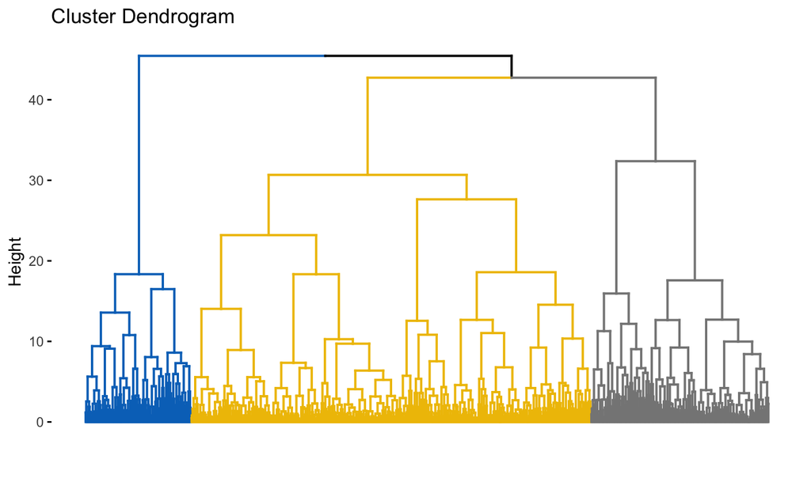

```r
# Hierarchical clustering
hc_clust = eclust(credit_num_s, "hclust", k = 3, hc_metric = "euclidean", hc_method = "ward.D2", graph = FALSE)
# Visualize dendrograms the clusters
fviz_dend(hc_clust, show_labels = FALSE, palette = "jco", as.ggplot = TRUE)
```

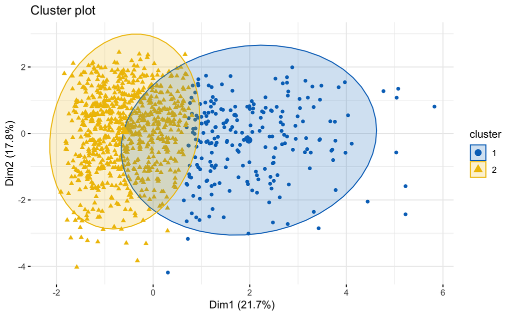

```r
# K-means clustering
km_clust = eclust(credit_num_s, "kmeans", k = 2, nstart = 25, graph = FALSE)
# Visualize k-means clusters
fviz_cluster(km_clust, geom = "point", ellipse.type = "norm",
             palette = "jco", ggtheme = theme_minimal())
```

```r
#Lets do the some Principal Component Analysis on the same numerical variable
credit_pca = prcomp(credit_num_s,
                 center = TRUE,
                 scale. = TRUE)
summary(credit_pca)
```

```
Importance of components:
                          PC1    PC2    PC3    PC4    PC5    PC6     PC7     PC8
Standard deviation     1.3187 1.1928 1.0811 0.9868 0.9496 0.9001 0.83744 0.53147
Proportion of Variance 0.2174 0.1778 0.1461 0.1217 0.1127 0.1013 0.08766 0.03531
Cumulative Proportion  0.2174 0.3952 0.5413 0.6631 0.7758 0.8770 0.96469 1.00000
```

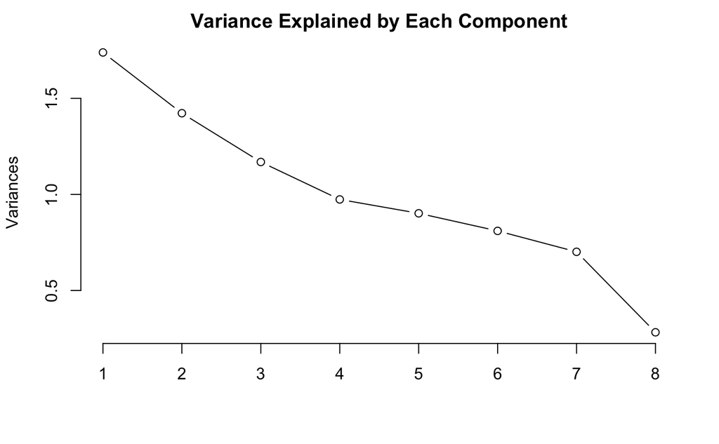

```r
principals_components = credit_pca$rotation
plot(credit_pca,main="Variance Explained by Each Component",type="l")
```

## [*Feedback Form*](https://goo.gl/forms/TQgzhsVSClfcWJT82)

# References

S. Moro, P. Cortez and P. Rita. A Data-Driven Approach to Predict the Success of Bank Telemarketing. Decision Support Systems, In press, http://dx.doi.org/10.1016/j.dss.2014.03.00

Gareth James, Daniela Witten, Trevor Hastie, and Robert Tibshirani. 2014. An Introduction to Statistical Learning: With Applications in R. Springer Publishing Company, Incorporated.

Hussami, N., Kraljevic, T., Lanford, J., Nykodym, T., Rao, A., and Wang, A. (Aug. 2015). Generalized Linear Modeling with H2O. http://h2o.ai/resources.

Computational Actuarial Science With R by Arthur Charpentier (editor), 2015, Boca Raton, FL: CRC Press, 618 pages, ISBN: 978‐1‐4665‐9259‐9.